# Activity: Bird Species

Guilherme Lima

6/7/23

# Set Up

```r
# Load `tidyverse` and `dcData` packages
library(tidyverse)
library(dcData)


# Load the `OrdwayBirds` data set into your RStudio environment from the `dcData` package
data("OrdwayBirds", package = "dcData")



# Show a few commands used to inspect the data set a few different ways
head(OrdwayBirds)
```

|  | bogus | Timestamp | Year | Day | Month | CaptureTime | SpeciesName | Sex | Age | BandNumber | TrapID | Weather | BandingReport | RecaptureYN | RecaptureMonth | RecaptureDay | Condition | Release | Comments | DataEntryPerson | Weight | WingChord | Temperature | RecaptureOriginal | RecapturePrevious | TailLength |
| --- | --- | --- | --- | --- | --- | --- | --- | --- | --- | --- | --- | --- | --- | --- | --- | --- | --- | --- | --- | --- | --- | --- | --- | --- | --- | --- |
| 3 | . | 4/14/2010 13:20:56 | 1972 | 16 | 7 | 7:00:00 | Song Sparrow | U | AHY (After Hatch Year) | 107-151187 | warbler | none | check mark in record | no check | none | none | none | none | none | Jerald Dosch |  |  |  |  |  |  |
| 4 | . |  |  |  |  |  |  |  |  |  |  |  |  |  |  |  |  |  |  | Caitlin Baker |  |  |  |  |  |  |
| 5 | . | 5/13/2010 16:00:30 | 1972 | 16 | 7 | 7:00:00 | Song Sparrow | U | AHY (After Hatch Year) | 107-151187 | Warbler | none | check mark in record | no check | none | none | none | none | none | Caitlin Baker |  |  |  |  |  |  |
| 6 | . | 5/13/2010 16:02:15 | 1972 | 16 | 7 | 7:00:00 | Field Sparrow | U | AHY (After Hatch Year) | 1260-74572 | Warbler | none | no check mark in record | check or yes | 7 | 9 | none | none | none | Caitlin Baker |  |  |  |  |  |  |
| 7 | . | 5/13/2010 16:03:18 | 1972 | 16 | 7 | 7:00:00 | Field Sparrow | U | AHY (After Hatch Year) | 1260-74541 | Elevator | none | no check mark in record | check or yes | 4 | 25 | none | none | none | Caitlin Baker |  |  |  |  |  |  |
| 8 | . | 5/13/2010 16:04:23 | 1972 | 16 | 7 | 7:00:00 | Song Sparrow | U | AHY (After Hatch Year) | 107-151188 | Elevator | none | check mark in record | no check | none | none | none | none | none | Caitlin Baker |  |  |  |  |  |  |

```r
#glimpse(OrdwayBirds)
summary(OrdwayBirds)
```

```
    bogus            Timestamp             Year               Day               Month
 Length:15829       Length:15829       Length:15829       Length:15829       Length:15829
 Class :character   Class :character   Class :character   Class :character   Class :character
 Mode  :character   Mode  :character   Mode  :character   Mode  :character   Mode  :character
 CaptureTime        SpeciesName            Sex                Age             BandNumber
 Length:15829       Length:15829       Length:15829       Length:15829       Length:15829
 Class :character   Class :character   Class :character   Class :character   Class :character
 Mode  :character   Mode  :character   Mode  :character   Mode  :character   Mode  :character
    TrapID            Weather          BandingReport      RecaptureYN        RecaptureMonth
 Length:15829       Length:15829       Length:15829       Length:15829       Length:15829
 Class :character   Class :character   Class :character   Class :character   Class :character
 Mode  :character   Mode  :character   Mode  :character   Mode  :character   Mode  :character
 RecaptureDay        Condition           Release            Comments         DataEntryPerson
 Length:15829       Length:15829       Length:15829       Length:15829       Length:15829
 Class :character   Class :character   Class :character   Class :character   Class :character
 Mode  :character   Mode  :character   Mode  :character   Mode  :character   Mode  :character
    Weight           WingChord         Temperature        RecaptureOriginal  RecapturePrevious
 Length:15829       Length:15829       Length:15829       Length:15829       Length:15829
 Class :character   Class :character   Class :character   Class :character   Class :character
 Mode  :character   Mode  :character   Mode  :character   Mode  :character   Mode  :character
  TailLength
 Length:15829
 Class :character
 Mode  :character
```

```r
#View(OrdwayBirds)
#names(OrdwayBirds)
```

# Activity

When you’re finished with this activity, you will have a graph that shows what time of year various species appear at the Katherine Ordway Natural History Study Area in Inver Grove Heights, MN.

### Step 0

Before we begin, the book gives us some instructions to select a few key variables and clean up the date formatting. Use the commands given in the book, but be sure to study the functions used so you know what is happening. In this case, we select `SpeciesName`, `Month`, and `Day`. Then a `mutate()` command converts each variable to character, and then converts the resulting “character string” to a number.

```r
# Get the data table & clean up dates (see Data Computing eBook)
OrdwayBirds <-
  OrdwayBirds %>%
  select( SpeciesName, Month, Day ) %>%
  mutate( Month = as.numeric(as.character(Month)),
          Day = as.numeric(as.character(Day)))


# Inspect resulting data
head(OrdwayBirds)
```

|  | SpeciesName | Month | Day |
| --- | --- | --- | --- |
| 3 | Song Sparrow | 7 | 16 |
| 4 |  | NA | NA |
| 5 | Song Sparrow | 7 | 16 |
| 6 | Field Sparrow | 7 | 16 |
| 7 | Field Sparrow | 7 | 16 |
| 8 | Song Sparrow | 7 | 16 |

```r
summary(OrdwayBirds)
```

```
 SpeciesName            Month             Day
 Length:15829       Min.   : 1.000   Min.   :   1.00
 Class :character   1st Qu.: 5.000   1st Qu.:   8.00
 Mode  :character   Median : 7.000   Median :  15.00
                    Mean   : 7.037   Mean   :  15.54
                    3rd Qu.:10.000   3rd Qu.:  23.00
                    Max.   :25.000   Max.   :1975.00
                    NA's   :4        NA's   :4
```

### Step 1

```r
# unique species in original data (including mis-spellings)
n_distinct(OrdwayBirds$SpeciesName)
```

```
[1] 275
```

```r
# unique species in the clean list
data("OrdwaySpeciesNames", package = "dcData")
n_distinct(OrdwaySpeciesNames$SpeciesNameCleaned)
```

```
[1] 109
```

275 Unique Species in original data

109 Unique Species in the clean list

### Step 2

```r
# inspect OrdwaySpeciesNames
head(OrdwaySpeciesNames)
```

|  | SpeciesName | SpeciesNameCleaned |
| --- | --- | --- |
| 1 |  | NA |
| 2 | -lost- | NA |
| 3 | -missing- | NA |
| 4 | [Nothing, just dashes] | NA |
| 5 | 13:00:00 | NA |
| 6 | Acadian Flycatcher | Acadian Flycatcher |

```r
summary(OrdwaySpeciesNames)
```

```
 SpeciesName        SpeciesNameCleaned
 Length:265         Length:265
 Class :character   Class :character
 Mode  :character   Mode  :character
```

```r
# inner join
Corrected <-
  OrdwayBirds %>%
  inner_join( OrdwaySpeciesNames ) %>%
  select( Species = SpeciesNameCleaned, Month, Day ) %>%
  na.omit()  # cleaned up the missing ones
# inspect the data after the join
head(Corrected)
```

|  | Species | Month | Day |
| --- | --- | --- | --- |
| 1 | Song Sparrow | 7 | 16 |
| 3 | Song Sparrow | 7 | 16 |
| 4 | Field Sparrow | 7 | 16 |
| 5 | Field Sparrow | 7 | 16 |
| 6 | Field Sparrow | 7 | 16 |
| 7 | Field Sparrow | 7 | 16 |

```r
summary(Corrected)
```

```
   Species              Month             Day
 Length:15144       Min.   : 1.000   Min.   :   1.00
 Class :character   1st Qu.: 5.000   1st Qu.:   8.00
 Mode  :character   Median : 7.000   Median :  15.00
                    Mean   : 7.113   Mean   :  15.55
                    3rd Qu.:10.000   3rd Qu.:  23.00
                    Max.   :25.000   Max.   :1975.00
```

EBook Q1: Which variable(s) was used for matching cases? SpeciesName was used for matching cases

### Step 3

We want to identify the top 5-6 bird species sighted at the Katherine Ordway Natural History Study Area.

```r
# count sightings by species in descending order
sightingsCount <- Corrected %>% group_by(Species) %>% summarise(count = n()) %>% arrange(desc(count))



# a hint in the text book recommends displaying the top 10 species to choose our threshold
sightingsCount %>% head(10)
```

| Species | count |
| --- | --- |
| Slate-colored Junco | 2732 |
| Tree Swallow | 1537 |
| Black-capped Chickadee | 1327 |
| American Goldfinch | 1204 |
| Field Sparrow | 1164 |
| Lincoln's Sparrow | 790 |
| Robin | 608 |
| Catbird | 554 |
| Song Sparrow | 512 |
| House Wren | 460 |

```r
sightingsThreshold <- sightingsCount$Species %>% head(6)


# define a sightings threshold; produce a table with only birds belonging to major species
Majors <- Corrected %>% filter(Species %in% sightingsThreshold)
```

### Step 4

We now want to produce a month-by-month count for each of the major species, and then construct a chart to tell the story of what time of year the various species appear.

```r
# prepare glyph-ready data table called `ByMonth`
ByMonth <- Majors %>% group_by(Species, Month) %>% summarise(count = n()) %>% arrange(Month)
```

Now use the ggplot template below to generate the desired graph. (Remark you can also use esquisser or mplot to create a line chart instead of the barchart)

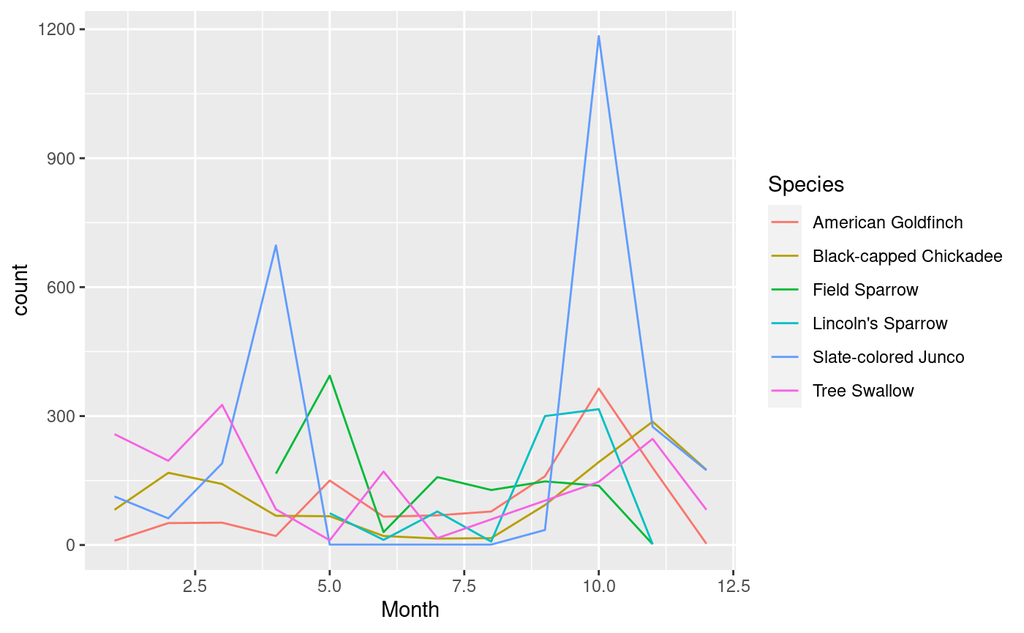

```r
# ggplot commands

ByMonth %>%
  ggplot(aes(x = Month, y = count, color = Species)) +
  geom_line()
```

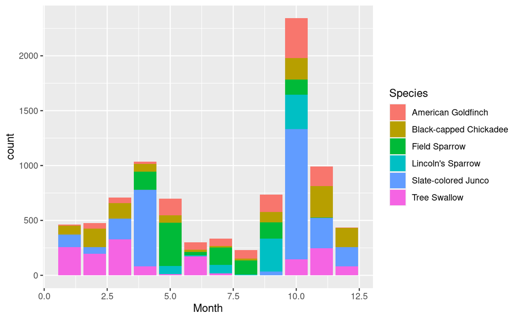

```r
ByMonth %>% ggplot(aes(x=Month,y=count ,fill=Species)) +
  geom_bar(stat='identity',position='stack', width=.9)
```

According to the graph, we can answer the questions posed:

##### 2. Which species are migratory, that is, primarily present in one or two seasons?

Lincoln’s Sparrow Slate-colored Junco

##### 3. What is the peak month for each major species? (bullet list)

*American Goldfinch: October* Black-capped Chickadee: November *Field Sparrow: May* Lincoln’s Sparrow: October *Slate-colored Junco: October* Tree Swallow: March

##### 4. Which major species are seen in good numbers for at least 6 months of the year?

American Goldfinch Black-capped Chickadee Field Sparrow Slate-colored Junco Tree Swallow